# CB3_Project

Matt Hirschi

December 15, 2018

```r
dat <- read_csv("basketball3.csv")
```

### Question

Is there a difference in the shots made by the type of shot they take, the distance they shoot from or the location on the basketball court or an interaction between 2 of the factors or all 3? My Hypothesis:

Ho: The mean for the levels of Type of Shot are equal. Ha: At least one mean is different. Ho: The mean for the levels of Distance are equal. Ha: At least one mean is different. Ho: The mean for the levels of Location are equal. Ha: At least one mean is different. Ho: No interaction between Type of Shot and Distance. Ha: Interaction between Type of Shot and Distance Ho: No interaction between Type of shot and Location. Ha: Interaction between Type of Shot and Location. Ho: No interaction between Distance and Location. Ha: Interaction between Distance and Location. Ho: No interaction between Type of Shot, Location and Distance. Ha: Interaction between Type of Shot, Location, and Distance.

### Randomization

I randomized by making 3 different arrays for the type of shot, the distance, and the location. I assigned Regular Shot 1 and Underhand 2, FreeThrow 1 and 3 pointer 2, and Front 1 and Side 2 and put them through a random number generator to assign how each individual shot until I had all of my data. The factors are Type of Shot, Distance and Location and the Response is Shots Made.

### Descriptive Statistics

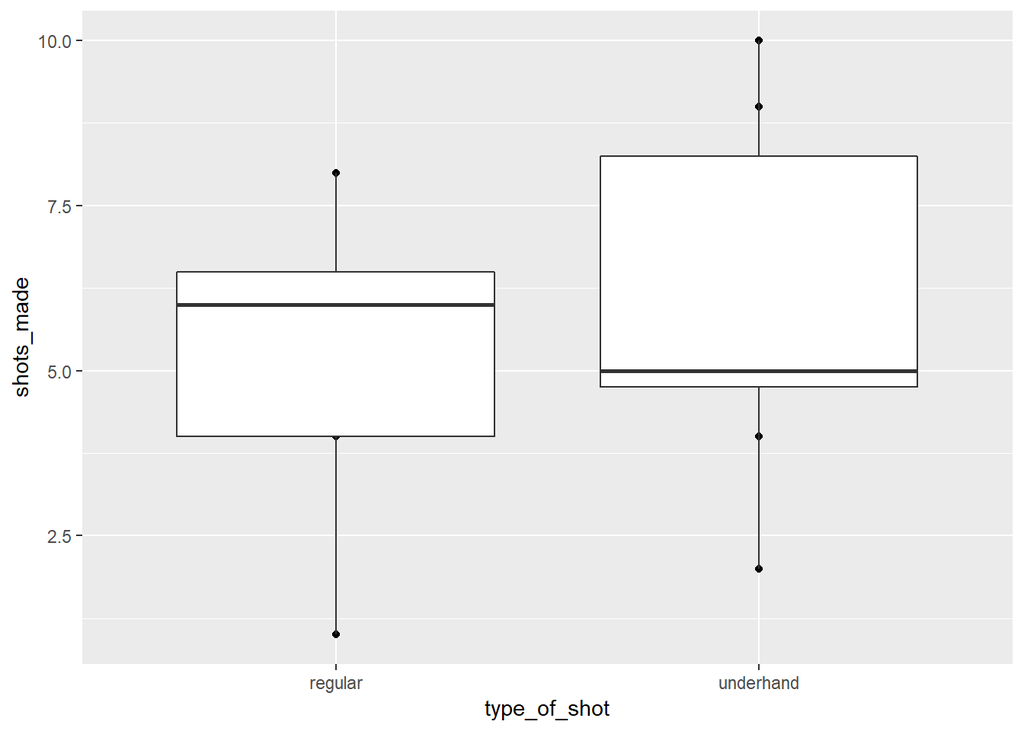

```r
dat %>%
  ggplot(aes(x = type_of_shot, y = shots_made))+
  geom_point()+
  geom_boxplot()
```

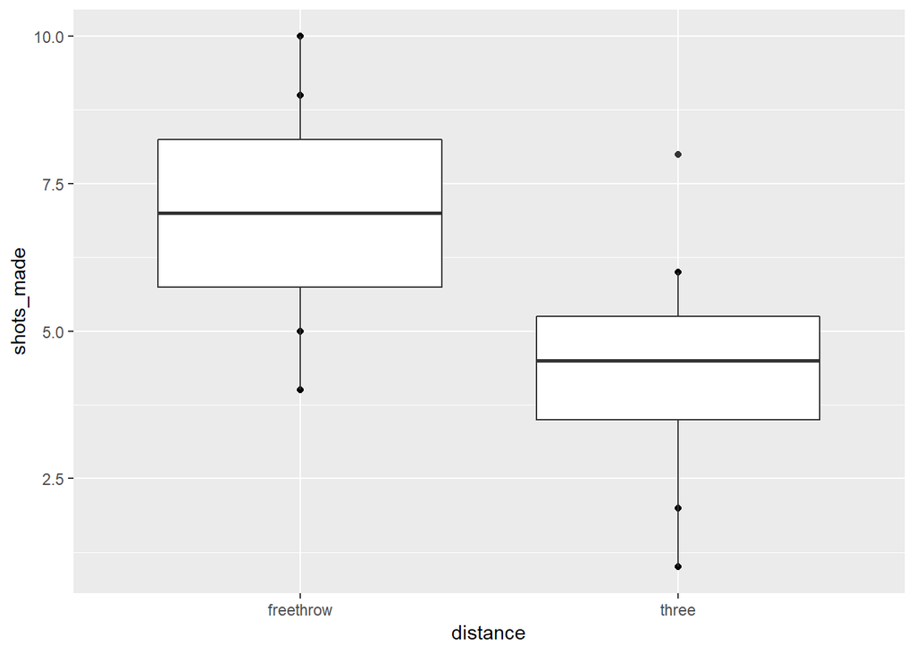

```r
dat %>%
  ggplot(aes(x = distance, y = shots_made))+
  geom_point()+
  geom_boxplot()
```

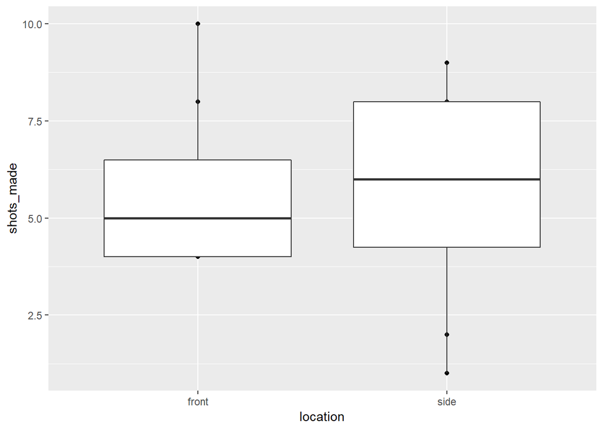

```r
dat %>%
  ggplot(aes(x = location, y = shots_made))+
  geom_point()+
  geom_boxplot()
```

```r
favstats(shots_made ~ type_of_shot, data = dat)
```

```
##   type_of_shot min   Q1 median   Q3 max  mean       sd n missing
## 1      regular   1 4.00      6 6.50   8 5.375 2.326094 8       0
## 2    underhand   2 4.75      5 8.25  10 6.000 2.725541 8       0
```

```r
favstats(shots_made ~ distance, data = dat)
```

```
##    distance min   Q1 median   Q3 max  mean       sd n missing
## 1 freethrow   4 5.75    7.0 8.25  10 7.000 2.070197 8       0
## 2     three   1 3.50    4.5 5.25   8 4.375 2.199838 8       0
```

```r
favstats(shots_made ~ location, data = dat)
```

```
##   location min   Q1 median  Q3 max  mean       sd n missing
## 1    front   4 4.00      5 6.5  10 5.750 2.187628 8       0
## 2     side   1 4.25      6 8.0   9 5.625 2.875388 8       0
```

The standard deviations are all close enough together to move onto the making of a model and testing for signicance.

### Inferential Statistics

The assumptions have been met. The residuals follow the qqplot pretty well to show normality and the residuals vs fitted plot shows constant variance so we will move on with the model.

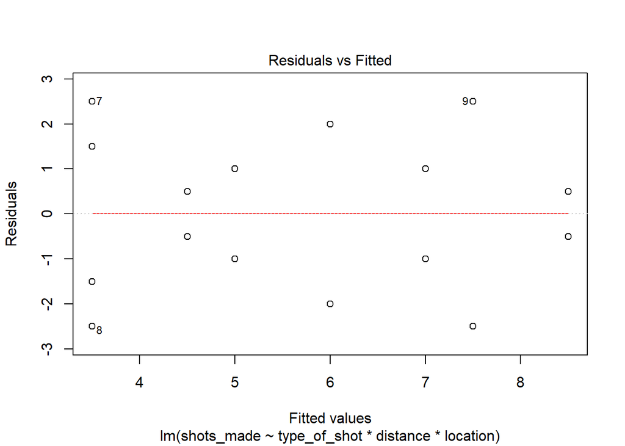

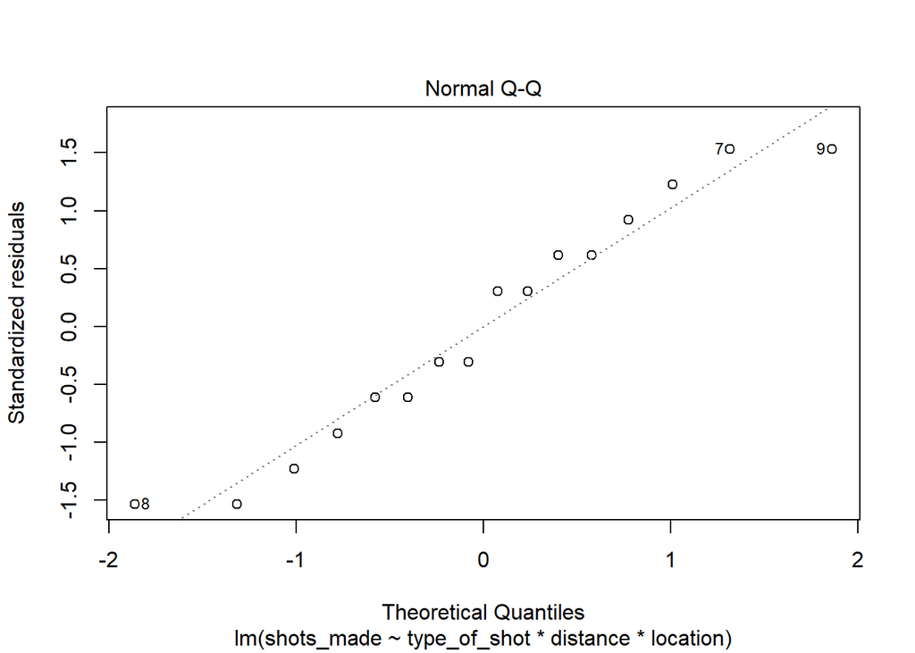

```r
model <- lm(shots_made ~ type_of_shot * distance * location,
            data = dat)
plot(model, which = 1:2)
```

```r
summary(model)
```

```
##
## Call:
## lm(formula = shots_made ~ type_of_shot * distance * location,
##     data = dat)
##
## Residuals:
##    Min     1Q Median     3Q    Max
## -2.500 -1.125  0.000  1.125  2.500
##
## Coefficients:
##                                                  Estimate Std. Error
## (Intercept)                                         5.000      1.630
## type_of_shotunderhand                               2.500      2.305
## distancethree                                       1.000      2.305
## locationside                                        2.000      2.305
## type_of_shotunderhand:distancethree                -4.000      3.260
## type_of_shotunderhand:locationside                 -1.000      3.260
## distancethree:locationside                         -4.500      3.260
## type_of_shotunderhand:distancethree:locationside    2.500      4.610
##                                                  t value Pr(>|t|)
## (Intercept)                                        3.068   0.0154 *
## type_of_shotunderhand                              1.085   0.3097
## distancethree                                      0.434   0.6759
## locationside                                       0.868   0.4108
## type_of_shotunderhand:distancethree               -1.227   0.2547
## type_of_shotunderhand:locationside                -0.307   0.7668
## distancethree:locationside                        -1.381   0.2048
## type_of_shotunderhand:distancethree:locationside   0.542   0.6024
## ---
## Signif. codes:  0 '***' 0.001 '**' 0.01 '*' 0.05 '.' 0.1 ' ' 1
##
## Residual standard error: 2.305 on 8 degrees of freedom
## Multiple R-squared:  0.5352, Adjusted R-squared:  0.1285
## F-statistic: 1.316 on 7 and 8 DF,  p-value: 0.352
```

I think I got the results I did because everyone had already been playing basketball for a while and was warmed up and knew that the experiment was coming.

I would have made them do this study cold and not warmed up and asked random strangers instead of people I knew.

The follow up studies I would do would be to choose people at random instead of do a convient sample of people I already know to participate.